# 03_computational_modeling_analysis - participant 6

DDM - value_scaling_t0 - wide bounds - DEoptimR

Bram Zandbelt

June 19, 2019

# 1 Overview

This notebook contains the **computational modeling analysis** of an individual participant’s data. The goal of this analysis is to determine the fit the intertemporal choice task performance data with a cognitive model, parameterized in a certain way to account for the framing effects.

The tasks that can be fit are:

- defer-speedup task;
- date-delay task.

The models the can be used to fit the task performance are:

- Drift Diffusion Model (`DDM`, choices and response times);
- Decision Field Theory (`DFT_C`, choices only; `DFT_CRT`, choices and response times),

The parameterizations that can used to account for the framing effects are:

- time scaling parameter ($\kappa$);
- value scaling parameter ($\mu$);
- time scaling parameter ($\kappa$) and value scaling parameter ($\mu$);
- time scaling parameter ($\kappa$) and non-decision-time ($T_{ER}$);
- value scaling parameter ($\mu$) and non-decision-time ($T_{ER}$);
- time scaling parameter ($\kappa$), value scaling parameter ($\mu$), and non-decision-time ($T_{ER}$);

This notebook takes as input a participant’s cleaned and preprocessed experiment data and produces as output visualizations and csv files written to disk of optimization statistics, best-fitting model parameter values, model fit to the data, and predicted indifference point curves and area under the curve statistics.

# 2 Preliminaries

Before reading the data, the following is specified:

```r
notebook_name <-
   stringr::str_to_lower(stringr::str_replace_all(params$title, " ", "_"))
```

- the *name of the notebook (`notebook_name`)*, which is used to save output (e.g. best-fitting parameters, a visual report) to a notebook-specific directory;

```r
# Raw trial log files are read from here
preprocessed_data_dir <-
  file.path("data","derivatives", "01_preprocessing", "included")

# Model optimization data will be written here
optimizations_dir <-
  file.path("data","derivatives", notebook_name)
converged_models_dir <-
  file.path(optimizations_dir, "converged")
nonconverged_models_dir <-
  file.path(optimizations_dir, "nonconverged")

# Figures will be written here
figures_dir <-
  file.path("figures", notebook_name)

# Create non-existing dirs if they don't exist
cmdsddfeitc::check_dir(all_dirs = c(preprocessed_data_dir,
                                    optimizations_dir,
                                    converged_models_dir,
                                    nonconverged_models_dir,
                                    figures_dir))
```

- all *relevant directories* for reading and writing data

```r
# Determine which file should be read
expt_standard_trials_filename <- list.files(path = preprocessed_data_dir,
                                            pattern = sprintf("^experiment_standard_trials_.*%.3d.csv$",
                                                              params$participant_id[[1]])
                                            )

# Determine task version, because factor levels (e.g. framing, trial_type) are task-dependent
task_version <- ifelse(stringr::str_detect(expt_standard_trials_filename, "defer_speedup"),
                    "defer_speedup",
                    ifelse(stringr::str_detect(expt_standard_trials_filename, "date_delay"),
                           "date_delay",
                           NA
                           )
                    )
```

- the paths to the *task performance files (`expt_standard_trials_filename`)* containing the data from the cleaned standard trials from the experiment and the _task version (`task_version`).

```r
# Parameterization & framing levels
parameterization <-
  ifelse(params$parameterization == "one_condition",
         params$parameterization,
         stringr::str_c(task_version, "_", params$parameterization)
         )

if (task_version == "defer_speedup") {
  framing_levels <- c("neutral", "defer", "speedup")
} else if (task_version == "date_delay") {
  framing_levels <- c("delay", "date")
}

# Parameter bounds
lowers <- itchmodel::get_par_bounds(model = params$model_name,
                                    parameterization = parameterization,
                                    bound = 'lower',
                                    bound_setting = params$bound_setting)
uppers <- itchmodel::get_par_bounds(model = params$model_name,
                                    parameterization = parameterization,
                                    bound = 'upper',
                                    bound_setting = params$bound_setting)

# Number of free parameters
n_free_params <- sum(!(lowers == uppers))

# Parameter names
par_names <- itchmodel::get_par_names(model = params$model_name, parameterization = parameterization)
par_names <- factor(par_names, levels = par_names, ordered = TRUE)

free_par_names <-
  par_names[!(lowers == uppers)]

free_par_lowers <- lowers[!(lowers == uppers)]
names(free_par_lowers) <- free_par_names
free_par_uppers <- uppers[!(lowers == uppers)]
names(free_par_uppers) <- free_par_names

# Tibble with bound values of free params
free_par_bounds_tibb <-
  dplyr::bind_rows(free_par_lowers, free_par_uppers) %>%
  dplyr::mutate(bound = c("lower", "upper")) %>%
  dplyr::select(bound, dplyr::everything())
```

- several variables relevant for modeling, including the *parameterization (`_parameterization`)*, *framing levels (`framing_levels`)*, *parameter bounds (`lowers`, `uppers`)*, among others.

```r
# Determine indifference points, given LL amount, LL delay, and best-fitting parameters
predict_ip <- function(m_l, t_l, parameters, frame) {

  if (frame == 'defer') {
    numerator_lh <- as.double(parameters["w"]) * 1 * m_l^as.double(parameters["alpha"])
  } else {
    numerator_lh <- as.double(parameters["w"]) * as.double(parameters["mu"]) * m_l^as.double(parameters["alpha"])
  }

  numerator_rh <- as.double(1 - (parameters["w"])) * as.double(parameters["kappa"]) * t_l^as.double(parameters["beta"])
  numerator <- numerator_lh - numerator_rh

  if (frame == 'speedup') {
    denominator <- as.double(parameters["w"]) * 1
  } else {
    denominator <- as.double(parameters["w"]) * as.double(parameters["mu"])
  }

  frac <- numerator/denominator
  frac[frac < 0] <- 0

  return(10^(log10(frac)/as.double(parameters["alpha"])))

}
```

- function for computing indifference points (`predict_ip`), based on amounts, delays, parmeter values, and frame.

# 3 Read data

Having specified all relevant variables, the cleaned standard trials from the experiment are read:

```r
# Read (and print) the data, using task-dependent column specifications
(expt_trials <-
    readr::read_csv(file = file.path(preprocessed_data_dir, expt_standard_trials_filename),
                    col_types = cmdsddfeitc::get_col_types(stringr::str_c("expt_standard_trials_",
                                                                          task_version)))
  )
```

| subject_ix | frame | m_s | m_s_cat | m_l | t_s | t_l | choice | response | rt |
| --- | --- | --- | --- | --- | --- | --- | --- | --- | --- |
| 6 | date | 42.84 | above_ip | 43.52 | 0 | 8 | ss | lower | 5.924606 |
| 6 | date | 33.32 | below_ip | 43.52 | 0 | 128 | ll | upper | 7.057739 |
| 6 | date | 39.78 | at_ip | 43.52 | 0 | 16 | ll | upper | 4.401692 |
| 6 | date | 34.00 | above_ip | 43.52 | 0 | 32 | ll | upper | 4.881368 |
| 6 | date | 41.14 | at_ip | 43.52 | 0 | 4 | ll | upper | 4.144198 |
| 6 | date | 33.66 | below_ip | 43.52 | 0 | 64 | ll | upper | 5.279331 |
| 6 | date | 34.00 | above_ip | 43.52 | 0 | 32 | ll | upper | 3.565276 |
| 6 | date | 42.84 | above_ip | 43.52 | 0 | 8 | ss | lower | 5.314809 |
| 6 | date | 35.70 | at_ip | 43.52 | 0 | 64 | ll | upper | 2.662434 |
| 6 | date | 30.60 | below_ip | 43.52 | 0 | 32 | ll | upper | 4.532304 |

[output cut: 157 more lines]

```r
# Get rid of trials that won't be used
if (params$parameterization == "one_condition") {
  if (task_version == "defer_speedup") {
    frame_cond <- "neutral"
  } else if (task_version == "date_delay") {
    frame_cond <- "delay"
  }

  expt_trials <-
    expt_trials %>%
    dplyr::filter(frame == frame_cond) %>%
    dplyr::mutate(frame = forcats::fct_drop(.$frame))

}

# Number of data points
n_data_points <- nrow(expt_trials)
```

# 4 Preprocess data

The task performance data is then cleaned and formatted for modeling and plotting purposes:

```r
# Delays for which to compute AUC
delays_ip <- seq(0,max(expt_trials$t_l),1)

# Count the number of data points
n_data_points <- nrow(expt_trials)

# Tidy & nest the observational data, as to prepare them for modeling
obs_nested <-
  cmdsddfeitc::tidy_obs_prd_choice_rt(return_var = "obs",
                                      obs = expt_trials)$obs_nested
```

- For modeling, the data is nested by frame and grouped into stimuli and observation variables.

## 4.1 Prepare observed data for plotting

```r
if (params$visualize) {
  obs_for_plotting <-
    obs_nested %>%
    dplyr::select(-stimuli, -observations) %>%
    tidyr::unnest()

  obs_for_plotting
}
```

| participant_id | frame | m_s_cat | m_s | t_s | m_l | t_l | p_ll | med_rt |
| --- | --- | --- | --- | --- | --- | --- | --- | --- |
| 6 | delay | below IP | 41.48 | 0 | 43.52 | 2 days | 1.00 | 1.830 |
| 6 | delay | at IP | 41.82 | 0 | 43.52 | 2 days | 1.00 | 4.540 |
| 6 | delay | above IP | 42.16 | 0 | 43.52 | 2 days | 1.00 | 5.940 |
| 6 | delay | below IP | 40.46 | 0 | 43.52 | 4 days | 1.00 | 4.715 |
| 6 | delay | at IP | 41.14 | 0 | 43.52 | 4 days | 1.00 | 1.975 |
| 6 | delay | above IP | 41.82 | 0 | 43.52 | 4 days | 1.00 | 5.880 |
| 6 | delay | below IP | 40.80 | 0 | 43.52 | 8 days | 1.00 | 6.775 |
| 6 | delay | at IP | 41.82 | 0 | 43.52 | 8 days | 1.00 | 5.705 |
| 6 | delay | above IP | 42.84 | 0 | 43.52 | 8 days | 0.50 | 6.165 |
| 6 | delay | below IP | 38.42 | 0 | 43.52 | 16 days | 1.00 | 4.415 |

[output cut: 32 more lines]

- For plotting, probability of choosing LL ($P(LL)$) is computed for each combination of frame (2 or 3 levels, depending on task), delay (7 levels), and SS amount category (3 levels).

# 5 Analyze data

## 5.1 Fit model to the data or just compute log-likelihood for given parameter values

```r
# Set seed for the random number generator, so that results can be reproduced
set.seed(19821101) # That's my DOB

if (params$optimize) {

  if (params$algorithm == "DEoptim") {
    # Optimization using bound constraints only

    optim_out <-
     DEoptim::DEoptim(fn = itchmodel::get_log_likelihood, # optimization function
                      lower = lowers, # lower bounds
                      upper = uppers, # upper bounds
                      control = list(itermax = params$max_iter,
                                     reltol = params$rel_tol,
                                     steptol = 200,
                                     NP = params$n_pop_per_free_param * n_free_params,
                                     trace = TRUE
                                     ),
                      # Additional arguments passed to fn and constr:
                      data = obs_nested,
                      model = params$model_name,
                      parameterization = parameterization
                      )

    # Store optimization function value and parameter values in variables ------
    optim_val_per_iter <- optim_out$member$bestvalit
    par_vals_per_iter <- optim_out$member$bestmemit
    n_iter <- optim_out$optim$iter
    colnames(par_vals_per_iter) <- par_names

    best_optim_val <- unname(optim_out$optim$bestval)
    best_par_val <- unname(optim_out$optim$bestmem)

  } else if (params$algorithm == "DEoptimR") {

    # DEoptimR took very long and very slowly converged to run for DDM models.
    # To address this, we start from the best-fitting DDM parameters obtained
    # with the DEoptim algorithm
    if (params$pars_from_file) {
      # Load the best-fitting parameters obtained with DEoptim, if this file exists

      best_par_val_file <-
        list.files(path = converged_models_dir,
                   pattern = sprintf("^best_fitting_params_task-.*_pid-%.3d_model-%s_pmz-%s_bounds-%s_algorithm-%s_BIC.*.csv$",
                                     params$participant_id, # pid
                                     params$model_name, # model
                                     params$parameterization, # pmz
                                     params$bound_setting, # bounds
                                     "DEoptim" # algorithm
                                     )
                   )
    } else {
      best_par_val_file <- "NA"
    }


    if (file.exists(file.path(converged_models_dir, best_par_val_file))) {
      best_par_val <-
        readr::read_csv(file = file.path(converged_models_dir, best_par_val_file),
                        col_types = readr::cols()) %>%
        dplyr::select(-participant_id, -model_name, -parameterization, -bound_settings, -algorithm) %>%
        as.double()

      optim_val_per_iter <- rep(NA, params$max_iter)
      par_vals_per_iter <- matrix(nrow = params$max_iter, ncol = length(lowers))
      colnames(par_vals_per_iter) <- par_names

      this_optim_val <- 1e6
      iter <- 0
      optim_out <-
        list(convergence = 1)

      while (optim_out$convergence == 1 & iter <= (params$max_iter - 1)) {

        iter <- iter + 1

        optim_out <-
       DEoptimR::JDEoptim(fn = itchmodel::get_log_likelihood, # optimization function
                          lower = lowers, # lower bounds
                          upper = uppers, # upper bounds
                          meq = 0,
                          constr = itchmodel::get_nonlinear_constraints,
                          maxiter = 1,
                          tol = params$rel_tol,
                          add_to_init_pop = as.matrix(best_par_val),
                          trace = TRUE,
                          details = TRUE,
                          # Additional arguments passed to fn and constr:
                          data = obs_nested,
                          model = params$model_name,
                          parameterization = parameterization,
                          pcrit = c(.75, .25)
                        )

        optim_val_per_iter[iter] <- optim_out$value
        par_vals_per_iter[iter,] <- optim_out$par
      }

    } else {

      # Optimization using bound constraints and nonlinear constraints
      # - Since DEoptimR::JDEoptim does not return iteration-wise optimization
      #   function values and parameter values, we implement this two step metho


      # Step 1 - Find reasonable starting parameter values (i.e. with likelihoods
      #   between 0.01 and 0.99 for all trials)
      optim_val_per_iter <- rep(NA, params$max_iter)
      par_vals_per_iter <- matrix(nrow = params$max_iter, ncol = length(lowers))
      colnames(par_vals_per_iter) <- par_names

      this_optim_val <- 1e6
      iter <- 1

      while (this_optim_val >= 1e6) {
        # This ensures that reasonable starting parameter values (i.e. likelihoods between 0.01 and 0.99 for all trials)
        optim_out <-
          DEoptimR::JDEoptim(fn = itchmodel::get_log_likelihood, # optimization function
                             lower = lowers, # lower bounds
                             upper = uppers, # upper bounds
                             constr = itchmodel::get_nonlinear_constraints,
                             meq = 0,
                             maxiter = 1,
                             tol = params$rel_tol,
                             NP = params$n_pop_per_free_param * n_free_params,
                             trace = TRUE,
                             details = TRUE,
                             # Additional arguments passed to fn and constr:
                             data = obs_nested,
                             model = params$model_name,
                             parameterization = parameterization,
                             pcrit = c(.75, .25)
                             )

        this_optim_val <- optim_out$value
        optim_val_per_iter[iter] <- optim_out$value
        par_vals_per_iter[iter,] <- optim_out$par
      }

      # Step 2 - Optimize parameter values and store intermediate optimization
      # function value and parameter values
      while (optim_out$convergence == 1 & iter <= (params$max_iter - 1)) {
```

```r
        iter <- iter + 1

        optim_out <-
         DEoptimR::JDEoptim(fn = itchmodel::get_log_likelihood, # optimization function
                            lower = lowers, # lower bounds
                            upper = uppers, # upper bounds
                            meq = 0,
                            constr = itchmodel::get_nonlinear_constraints,
                            maxiter = 1,
                            tol = params$rel_tol,
                            NP = 0,
                            add_to_init_pop = optim_out$poppar,
                            trace = TRUE,
                            details = TRUE,
                            # Additional arguments passed to fn and constr:
                            data = obs_nested,
                            model = params$model_name,
                            parameterization = parameterization,
                            pcrit = c(.75, .25)
                          )

        optim_val_per_iter[iter] <- optim_out$value
        par_vals_per_iter[iter,] <- optim_out$par
      }
    }

    # Store optimization function value and parameter values in variables ------
    best_optim_val <- optim_out$value
    best_par_val <- optim_out$par
    n_iter <- iter
  }

  # Convert optim_val_per_iter to tidy tibble for plotting purposes
  optim_val_per_iter_tibb <-
    tibble::as.tibble(na.exclude(optim_val_per_iter))
  colnames(optim_val_per_iter_tibb) <- "fun_val"
  optim_val_per_iter_tibb <-
    optim_val_per_iter_tibb %>%
    dplyr::mutate(iter = 1:n()) %>%
    dplyr::select(iter, fun_val)

  # Convert par_vals_per_iter to tidy tibble for plotting  and saving purposes
  par_vals_per_iter_tibb <-
    tibble::as.tibble(na.exclude(par_vals_per_iter)) %>%
    dplyr::mutate(iter = 1:n()) %>%
    dplyr::select(iter, as.character(par_names)) %>%
    tidyr::drop_na()

  free_par_vals_per_iter_tibb <-
    par_vals_per_iter_tibb %>%
    dplyr::select(iter, as.character(free_par_names)) %>%
    tidyr::gather(key = "key",
                  value = "value",
                  as.character(free_par_names),
                  factor_key = TRUE)

} else {
  # Do not optimize, but use parameter values loaded from disk or specified in params$par_vals

  if (params$pars_from_file) {

    # Optimization output statistics: used to determined convergence
    optim_out_stats_file_pattern <-
      sprintf("^optim_stats_task-.*_pid-%.3d_model-%s_pmz-%s_bounds-%s_algorithm-%s_BIC.*.csv$",
              params$participant_id, # pid
              params$model_name, # model
              params$parameterization, # pmz
              params$bound_setting, # bounds
              params$algorithm # algorithm
              )

    optim_out_stats_file <-
      list.files(path = converged_models_dir,
                 pattern = optim_out_stats_file_pattern
                 )

    # If the file is empty, it is possible that the optimization has not converged onto a minimum, so check nonconverged_models_dir
    if (length(optim_out_stats_file) == 0) {
      optim_out_stats_file <-
        list.files(path = nonconverged_models_dir,
                   pattern = optim_out_stats_file_pattern
                   )
      source_data_dir <- nonconverged_models_dir
    } else {
      source_data_dir <- converged_models_dir
    }


    assertthat::assert_that(length(optim_out_stats_file) == 1,
                            msg = "Multiple (or no) optimization output files (optim_out_stats_file) detected; unclear which one to select.")

    optim_out_stats <-
      readr::read_csv(file.path(source_data_dir, optim_out_stats_file),
                      col_types = readr::cols())
    n_iter <- optim_out_stats$n_iter

    optim_val_per_iter_file <-
      list.files(path = source_data_dir,
                 pattern = sprintf("^evolution_of_fun_val_across_iters_task-.*_pid-%.3d_model-%s.*_pmz-%s_bounds-%s_algorithm-%s.*.csv$",
                                   params$participant_id, # pid
                                   params$model_name, # model
                                   params$parameterization, # pmz
                                   params$bound_setting, # bounds
                                   params$algorithm # algorithm
                                   )
                 )

    assertthat::assert_that(length(optim_val_per_iter_file) == 1,
                            msg = "Multiple optimization value files (optim_val_per_iter_file) detected; unclear which one to select.")

    optim_val_per_iter_tibb <-
      readr::read_csv(file.path(source_data_dir, optim_val_per_iter_file),
                      col_types = readr::cols()) %>%
      tidyr::drop_na() %>%
      dplyr::select(iter, fun_val)

    best_optim_val <-
      optim_val_per_iter_tibb %>%
      dplyr::slice(n_iter) %>% # Last entry is best value
      dplyr::pull(fun_val)

    par_vals_per_iter_file <-
      list.files(path = source_data_dir,
                 pattern = sprintf("^evolution_of_params_across_iters_task-.*_pid-%.3d_model-%s_pmz-%s_bounds-%s_algorithm-%s_BIC.*.csv$",
                                   params$participant_id, # pid
                                   params$model_name, # model
                                   params$parameterization, # pmz
                                   params$bound_setting, # bounds
                                   params$algorithm # algorithm
                                   )
                 )

    assertthat::assert_that(length(par_vals_per_iter_file) == 1,
                            msg = "Multiple parameter values files (par_vals_per_iter_file) detected; unclear which one to select.")

    par_vals_per_iter <-
      readr::read_csv(file.path(source_data_dir, par_vals_per_iter_file),
                      col_types = readr::cols()) %>%
      dplyr::select(iter, as.character(par_names)) %>%
      tidyr::drop_na()

    free_par_vals_per_iter_tibb <-
      par_vals_per_iter %>%
      dplyr::select(iter, as.character(free_par_names)) %>%
      tidyr::gather(key = "key",
                    value = "value",
                    as.character(free_par_names),
                    factor_key = TRUE)
```

```r
    best_par_val_file <-
      list.files(path = source_data_dir,
                 pattern = sprintf("^best_fitting_params_task-.*_pid-%.3d_model-%s_pmz-%s_bounds-%s_algorithm-%s.*.csv$",
                                   params$participant_id, # pid
                                   params$model_name, # model
                                   params$parameterization, # pmz
                                   params$bound_setting, # bounds
                                   params$algorithm # algorithm
                 )
      )

    assertthat::assert_that(length(best_par_val_file) == 1,
                            msg = "Multiple best-fitting parameter values files (best_par_val_file) detected; unclear which one to select.")

    best_par_val <-
      readr::read_csv(file = file.path(source_data_dir, best_par_val_file),
                      col_types = readr::cols()) %>%
      dplyr::select(-participant_id, -model_name, -parameterization, -bound_settings, -algorithm) %>%
      as.double()

    # Further processing of par_vals_per_iter for use in optim_stat
    par_vals_per_iter <-
      par_vals_per_iter %>%
      dplyr::select(-iter)
    colnames(par_vals_per_iter) <-
      stringr::str_c("par", seq(1,length(best_par_val)))
    par_vals_per_iter <-
      par_vals_per_iter %>%
      as.matrix()

  } else {

    # Parameter values (N.B. not necessarily best-fitting, but for naming consistency)
    best_par_val <- params$par_vals

    n_iter <- 1

    par_vals_per_iter_tibb <-
      best_par_val %>%
      tibble::as.tibble() %>%
      dplyr::mutate(key = par_names) %>%
      tidyr::spread(key = key, value = value) %>%
      dplyr::mutate(iter = n_iter) %>%
      dplyr::select(iter, dplyr::everything())

    free_par_vals_per_iter_tibb <-
      par_vals_per_iter_tibb %>%
      dplyr::select(iter, as.character(free_par_names)) %>%
      tidyr::gather(key = "key",
                    value = "value",
                    as.character(free_par_names),
                    factor_key = TRUE)

    # Compute negative log-likelihood
    negative_log_likelihood <-
      itchmodel::get_log_likelihood(x = best_par_val,
                                    data = obs_nested,
                                    model = params$model_name,
                                    parameterization = parameterization)

    optim_val_per_iter_tibb <-
      tibble::tibble(iter = 1,
                     fun_val = negative_log_likelihood)

    best_optim_val <- negative_log_likelihood

  }

  # Make mock optim_out variable for the rest of the notebook code to work
  if (params$algorithm == "DEoptim") {
    optim_out <-
    list(member = list(bestvalit = best_optim_val,
                       bestmemit = ifelse(params$pars_from_file,
                                          par_vals_per_iter,
                                          matrix(best_par_val,
                                                 nrow = 1,
                                                 dimnames = list(1,
                                                                 stringr::str_c("par", seq(1,length(best_par_val))))
                                                 )
                                          ),
                       bestmem = best_par_val),
         optim = list(bestval = best_optim_val,
                      iter = ifelse(params$pars_from_file,
                                    nrow(par_vals_per_iter),
                                    1)
                      )
         )
  } else if (params$algorithm == "DEoptimR") {

    optim_out <-
      list(value = best_optim_val,
           par = best_par_val,
           iter = ifelse(params$pars_from_file,
                         nrow(par_vals_per_iter),
                         1),
           convergence = ifelse(params$pars_from_file,
                                ifelse(optim_out_stats$converged,
                                       0, #  0 indicates successful completion
                                       1), #  1 means that iteration limits has been reached
                                1)


           )
  }
}

# Store best-fitting parameter values per frame in a variable for later use
best_par_val_per_frame <-
    itchmodel::get_par_values(x = best_par_val,
                              model = params$model_name,
                              parameterization = parameterization)
  if (!is.list(best_par_val_per_frame)) {
    best_par_val_per_frame <- list(best_par_val_per_frame)
  }
```

If `params$optimize` is set to `TRUE`, the model (`params$model_name`) with a certain parameterization (`params$parameterization`) is fit to the data. Depending on the model, only choices are fit (`DFT_C`) or both choices and response times are fit (`DDM`, `DFT_CRT`). Model parameter values are optimized by minimizing negative log-likelihood using a differential evolution algorithm with bounds and nonlinear constraints (`DEOptimR`) or with bounds only (`DEoptim`). The bounds are largely based on previous studies (see `itchmodel::get_par_bounds`) and ensure that parameters take sensible values. The nonlinear constraints (`DEoptimR` only) ensure that that P(choosing LL) > 0.95 when SS amount equals €0 and P(choosing LL) < 0.05 0 when SS amount equals the LL amount (i.e. resulting in more meaningful parameter values).

Alternatively, if `params$optimize` is set to `FALSE`, the parameter values specified in `params$par_vals` are used to compute the log-likelihood. This is useful if you want to test whether other parameter value combinations provide a better fit.

## 5.2 Make model predictions based on best-fitting parameters

After fitting, the predicted data are prepared for plotting.

```r
# Put parameter values in right format for tidying
if (params$algorithm == "DEoptim") {
  par_vals <- optim_out$member$bestmem
  names(par_vals) <- par_names
} else if (params$algorithm == "DEoptimR") {
  par_vals <- optim_out$par
  names(par_vals) <- par_names
}

par_vals_output <-
  dplyr::bind_rows(par_vals) %>%
  dplyr::mutate(participant_id = params$participant_id,
                model_name = params$model_name,
                parameterization = params$parameterization,
                bound_settings = params$bound_setting,
                algorithm = params$algorithm) %>%
  dplyr::select(participant_id, model_name, parameterization, bound_settings, dplyr::everything())

# Retrieve observed data, predicted data, and intermediate modeling parameters
obs_and_prds <-
  cmdsddfeitc::tidy_obs_prd_choice_rt(return_var = 'all',
                                      obs = expt_trials,
                                      model = params$model_name,
                                      pmz = stringr::str_c(task_version, params$parameterization, sep = "_"),
                                      parameters = par_vals_output)
```

## 5.3 Determine indifference points and area under the curve based on model fits

```r
prds <-
  obs_and_prds$all_nested %>%
  dplyr::mutate(ip = purrr::pmap(.l = list(parameters = .$parameters,
                                           frame = as.character(.$frame)),
                                 .f = predict_ip,
                                 m_l = rep(43.52, length(delays_ip)),
                                 t_l = delays_ip)) %>%
  dplyr::mutate(auc = purrr::pmap(.l = list(y = .$ip),
                                  .f = DescTools::AUC,
                                  x = delays_ip,
                                  method = "trapezoid"))
```

## 5.4 Tidy choice probability data for plotting

```r
if (params$visualize) {
  prd_pll_for_plot <-
    obs_and_prds$prd_nested %>%
    dplyr::select(frame, stimuli, p_ll) %>%
    tidyr::unnest() %>%
    dplyr::mutate(t_l = factor(t_l,
                               levels = c(2,4,8,16,32,64,128),
                               labels = c("2 days", "4 days", "8 days", "16 days",
                                          "32 days", "64 days", "128 days"),
                               ordered = TRUE))

  prd_pll_for_plot
}
```

| frame | p_ll | t_l | t_s | m_l | m_s |
| --- | --- | --- | --- | --- | --- |
| delay | 1.000000000 | 2 days | 0 | 43.52 | 0.00 |
| delay | 1.000000000 | 2 days | 0 | 43.52 | 0.17 |
| delay | 1.000000000 | 2 days | 0 | 43.52 | 0.34 |
| delay | 1.000000000 | 2 days | 0 | 43.52 | 0.51 |
| delay | 1.000000000 | 2 days | 0 | 43.52 | 0.68 |
| delay | 1.000000000 | 2 days | 0 | 43.52 | 0.85 |
| delay | 1.000000000 | 2 days | 0 | 43.52 | 1.02 |
| delay | 1.000000000 | 2 days | 0 | 43.52 | 1.19 |
| delay | 1.000000000 | 2 days | 0 | 43.52 | 1.36 |
| delay | 1.000000000 | 2 days | 0 | 43.52 | 1.53 |

[output cut: 3588 more lines]

## 5.5 Tidy indifference point data and area-under-the-curve data for plotting and writing to disk

```r
prd_ip_data <-
  prds %>%
  dplyr::select(frame, ip) %>%
  tidyr::unnest() %>%
  dplyr::mutate(delay = rep(delays_ip, nrow(prds)))

prd_ip_data
```

| frame | ip | delay |
| --- | --- | --- |
| delay | 43.52000 | 0 |
| delay | 42.54857 | 1 |
| delay | 42.24918 | 2 |
| delay | 42.03312 | 3 |
| delay | 41.85801 | 4 |
| delay | 41.70819 | 5 |
| delay | 41.57587 | 6 |
| delay | 41.45654 | 7 |
| delay | 41.34730 | 8 |
| delay | 41.24620 | 9 |

[output cut: 248 more lines]

## 5.6 Tidy response time data for plotting

```r
if (params$visualize & params$model_name %in% c("DDM", "DFT_CRT")) {

  stimuli <-
    obs_and_prds$obs_nested %>%
    dplyr::select(-summary_stats) %>%
    tidyr::unnest() %>%
    dplyr::distinct(participant_id, frame, m_s_cat, m_s, t_s, m_l, t_l) %>%
    dplyr::mutate(frame = factor(frame,
                                 levels = itchmodel::get_frames(parameterization),
                                 ordered = TRUE)) %>%
    dplyr::group_by(participant_id, frame) %>%
    tidyr::nest(.key = stimuli)

  parameters <-
    obs_and_prds$all_nested %>%
    dplyr::select(participant_id, frame, parameters)

  stim_params_d_tmp <-
    dplyr::left_join(stimuli, parameters, by = c("participant_id", "frame")) %>%
    dplyr::mutate(d = purrr::pmap(.l = list(frame = as.character(.$frame),
                                            parameters = .$parameters,
                                            stimuli = .$stimuli),
                                  .f = itchmodel::compute_drift_rate,
                                  parameterization = stringr::str_c(task_version, params$parameterization, sep = "_")
                                  )
                  )

  if (params$model_name == "DFT_CRT") {
    stim_params_d_tmp <-
      stim_params_d_tmp %>%
      dplyr::mutate(du = purrr::pmap(.l = list(parameters = .$parameters,
                                               stimuli = .$stimuli,
                                               frame = as.character(.$frame)),
                                     .f = itchmodel::compute_transformation_diffs,
                                     parameterization = stringr::str_c(task_version, params$parameterization, sep = "_"),
                                   variable = "du"),
                    dp = purrr::pmap(.l = list(parameters = .$parameters,
                                               stimuli = .$stimuli,
                                               frame = as.character(.$frame)),
                                     .f = itchmodel::compute_transformation_diffs,
                                     parameterization = stringr::str_c(task_version, params$parameterization, sep = "_"),
                                     variable = "dp")) %>%
      dplyr::mutate(s = purrr::pmap(.l = list(d = .$d,
                                              du = .$du,
                                              dp = .$dp,
                                              parameters = .$parameters),
                                    .f = function(d, du, dp, parameters) {
                                      sqrt(rep(as.double(parameters["w"]), length(d)) * du^2 + (1 - rep(as.double(parameters["w"]), length(d))) * dp^2 - d^2)
                                    }
                                    )
                    )
  }

  # Relevant columns
  rel_cols <- c("participant_id","frame","type","m_s_cat","m_s","t_s","m_l","t_l","med_rt")

  stim_d <- stim_params_d_tmp %>% dplyr::select(-parameters) %>% tidyr::unnest()
  parameters <- parameters %>% tidyr::unnest()
  stim_params_d <-
    dplyr::left_join(x = stim_d, y = parameters, by = c("participant_id", "frame"))

  if (params$model_name == "DDM") {
    stim_params_d <-
      stim_params_d %>%
      dplyr::mutate(med_rt = purrr::pmap_dbl(.l = list(a = .$a,
                                                       v = .$d,
                                                       t0 = .$t0,
                                                       z = 0.5* .$a),
                                             .f = rtdists::qdiffusion,
                                             response = "upper", # For typical values, predictions for median RTs were found not to differ between "lower" and "upper" responses, hence only "upper"
                                             s = 1,
                                             p = 0.5,
                                             scale_p = TRUE)
                  )
  } else if (params$model_name == "DFT_CRT") {
    stim_params_d <-
      stim_params_d %>%
      dplyr::mutate(med_rt = purrr::pmap_dbl(.l = list(s = .$s,
                                                       a = .$theta_star *.$s,
                                                       v = .$d,
                                                       t0 = .$t0,
                                                       z = 0.5 * .$theta_star *.$s),
                                            .f = rtdists::qdiffusion,
                                            response = "upper", # For typical values, predictions for median RTs were found not to differ between "lower" and "upper" responses, hence only "upper"
                                            p = 0.5,
                                            scale_p = TRUE)
                    )
  }

  stim_params_d <-
      stim_params_d %>%
      dplyr::mutate(type = "prd") %>%
      dplyr::mutate(t_l = factor(t_l,
                                 levels = c(2,4,8,16,32,64,128),
                                 labels = c("2 days", "4 days", "8 days", "16 days",
                                            "32 days", "64 days", "128 days"),
                                 ordered = TRUE)) %>%
      dplyr::select(rel_cols)

  # Summary stats - observations
  obs_summary_stats <-
    obs_nested %>%
    dplyr::mutate(frame = factor(frame,
                                 levels = itchmodel::get_frames(parameterization),
                                 ordered = TRUE)) %>%
    dplyr::select(-stimuli, -observations) %>%
    tidyr::unnest() %>%
    dplyr::mutate(type = "obs",
                  m_s_cat = forcats::fct_recode(m_s_cat,
                                                below_ip = "below IP",
                                                at_ip = "at IP",
                                                above_ip = "above IP"
                                                )
                  ) %>%
    dplyr::select(rel_cols)

  # Merge observed and predicted median RTs
  rt_data_plot <- dplyr::bind_rows(obs_summary_stats, stim_params_d)


  obs_mdrt_for_plot <- rt_data_plot %>% dplyr::filter(type == "obs") %>% dplyr::ungroup()
  prd_mdrt_for_plot <- rt_data_plot %>% dplyr::filter(type == "prd") %>% dplyr::ungroup()

}
```

# 6 Visualize data

## 6.1 Optimization process

### 6.1.1 Optimization descriptives

```r
optim_stats <-
  itchmodel::get_fit_stats(optim_output = optim_out,
                           algorithm = params$algorithm,
                           model = params$model_name,
                           parameterization = parameterization,
                           n_data_points = n_data_points,
                           max_iter = params$max_iter)

# n_iter in optim_out does not reflect the actual number of iterations, because we do iterations in a loop
optim_stats$n_iter = n_iter

optim_stats
```

| model | parameterization | n_iter | converged | LL | AIC | BIC |
| --- | --- | --- | --- | --- | --- | --- |
| DDM | date_delay_value_scaling_t0 | 494 | TRUE | -387.5279 | 789.0558 | 810.8818 |

### 6.1.2 Best-fitting parameters values and lower and upper bounds

```r
best_fitting_par_values <-
  tibble(frame = factor(itchmodel::get_frames(parameterization = parameterization), ordered = TRUE),
         params = itchmodel::get_par_values(x = best_par_val,
                                            model = params$model_name,
                                            parameterization = parameterization)
         ) %>%
  dplyr::mutate(r = purrr::map(params, ~ data.frame(t(.)))) %>%
  tidyr::unnest(r) %>%
  dplyr::select(-params)

best_fitting_par_values
```

| frame | alpha | mu | beta | kappa | w | a | t0 |
| --- | --- | --- | --- | --- | --- | --- | --- |
| delay | 0.7280698 | 1.0000000 | 0.388954 | 1 | 0.797273 | 4.124128 | 1.243131 |
| date | 0.7280698 | 0.9972892 | 0.388954 | 1 | 0.797273 | 4.124128 | 1.171227 |

```r
free_par_bounds_tibb
```

| bound | alpha | mu2 | beta | w | a | t01 | t02 |
| --- | --- | --- | --- | --- | --- | --- | --- |
| lower | 0.01 | 0 | 0.01 | 0.00001 | 1e-03 | 0.05 | 0.05 |
| upper | 3.00 | 3 | 3.00 | 0.99999 | 1e+01 | 3.00 | 3.00 |

### 6.1.3 Evolution of parameter values over iterations

How did values of free model parameters evolve over iterations? Did the model optimzation routine converge? Do best-fitting parameter values end up at bounds

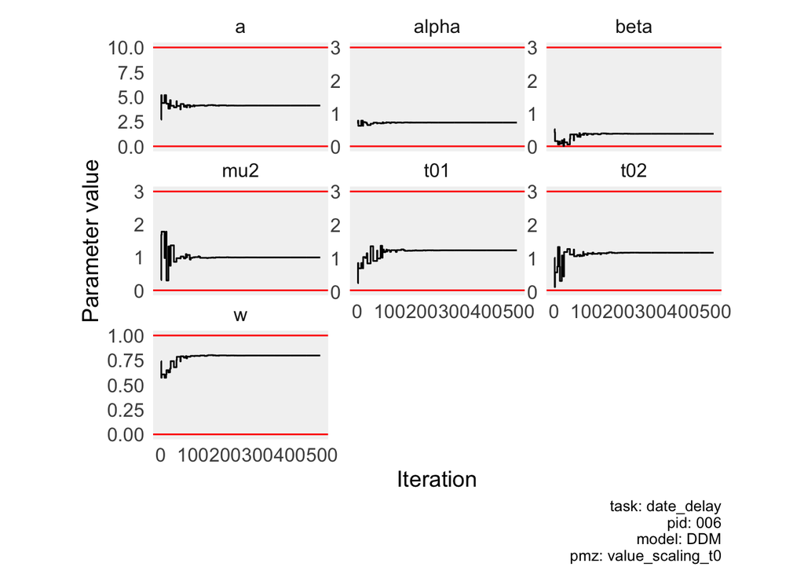

```r
if (params$visualize) {
 h_line_data <-
    free_par_bounds_tibb %>%
    tidyr::gather(key = "key", value = "value", -bound) %>%
    tidyr::spread(key = bound, value = value)

 plt_free_par_vals_per_iter_tibb <-
   ggplot2::ggplot(free_par_vals_per_iter_tibb,
                   ggplot2::aes(x = iter,
                                y = value)) +
   ggplot2::facet_wrap("key",
                       scales = "free_y") +
   ggplot2::geom_hline(data = h_line_data,
                       ggplot2::aes(yintercept = lower),
                       color = "red") +
   ggplot2::geom_hline(data = h_line_data,
                       ggplot2::aes(yintercept = upper),
                       color = "red") +
   ggplot2::geom_step() +
   ggplot2::scale_x_continuous(name = "Iteration") +
   ggplot2::scale_y_continuous(name = "Parameter value") +

   # Title
    ggplot2::labs(caption = sprintf("task: %s\npid: %.3d\nmodel: %s\npmz: %s",
                                       task_version,
                                       params$participant_id, # pid
                                       params$model_name, # model
                                       params$parameterization) # parameterization
                  ) +

   cmdsddfeitc::theme_cmfsddfeitc()

 print(plt_free_par_vals_per_iter_tibb)
}
```

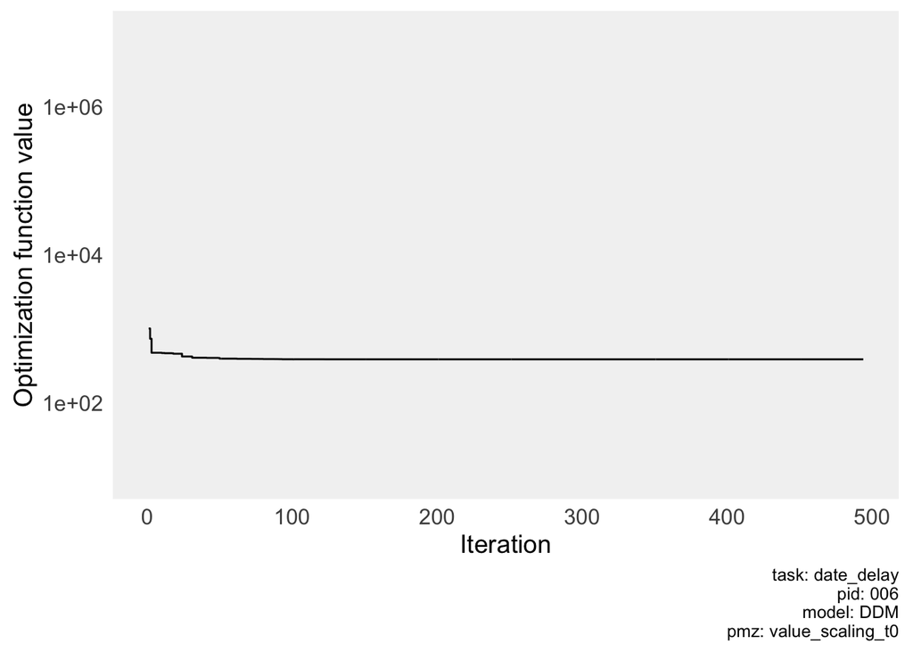

```r
if (params$visualize) {
  plt_optim_val_per_iter_tibb <-
    ggplot2::ggplot(optim_val_per_iter_tibb %>% dplyr::slice(1:n_iter),
                    ggplot2::aes(x = iter,
                                 y = fun_val)) +
    ggplot2::geom_step() +
    ggplot2::scale_x_continuous(name = "Iteration") +
    ggplot2::scale_y_continuous(name = "Optimization function value",
                                limits = c(1e1,1e7),
                                trans="log10") +

    # Title
    ggplot2::labs(caption = sprintf("task: %s\npid: %.3d\nmodel: %s\npmz: %s",
                                       task_version,
                                       params$participant_id, # pid
                                       params$model_name, # model
                                       params$parameterization) # parameterization
                  ) +

    cmdsddfeitc::theme_cmfsddfeitc()

  print(plt_optim_val_per_iter_tibb)
}
```

## 6.2 Observed vs. predicted data

### 6.2.1 Probability of choosing the LL option

This visualization highlights differences between frames, if any

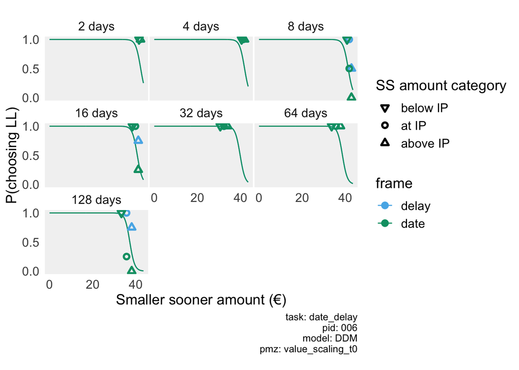

```r
if (params$visualize) {
  plt_obs_prd_ll_choices_compressed <-
    ggplot2::ggplot(data = prd_pll_for_plot,
                    ggplot2::aes(x = m_s,
                                 y = p_ll,
                                 group = frame,
                                 color = frame)) +
    ggplot2::facet_wrap("t_l") +
    ggplot2::geom_line() +
    ggplot2::geom_point(data = obs_for_plotting,
                        ggplot2::aes(x = m_s,
                                     y = p_ll,
                                     color = frame,
                                     shape = m_s_cat),
                        stroke = 1.5) +
    ggplot2::scale_x_continuous(name = "Smaller sooner amount (€)",
                                breaks = c(0, 20, 40),
                                limits = c(0,43.52)
                                ) +
    ggplot2::scale_y_continuous(name = "P(choosing LL)",
                                breaks = seq(0,1,0.5),
                                limits = c(0,1)) +
    ggplot2::scale_shape_manual(name = "SS amount category",
                                values = c(6,1,2)) +
    ggplot2::scale_color_manual(values = cmdsddfeitc::get_aes_values("color", parameterization)) +


    # Title
    ggplot2::labs(caption = sprintf("task: %s\npid: %.3d\nmodel: %s\npmz: %s",
                                       task_version,
                                       params$participant_id, # pid
                                       params$model_name, # model
                                       params$parameterization) # parameterization
                  ) +

    cmdsddfeitc::theme_cmfsddfeitc() +
    ggplot2::theme(legend.position = "right",
                   legend.direction = "vertical",
                   legend.box = "vertical")

  print(plt_obs_prd_ll_choices_compressed)
}
```

This visualization allows for checking model fit more precisely

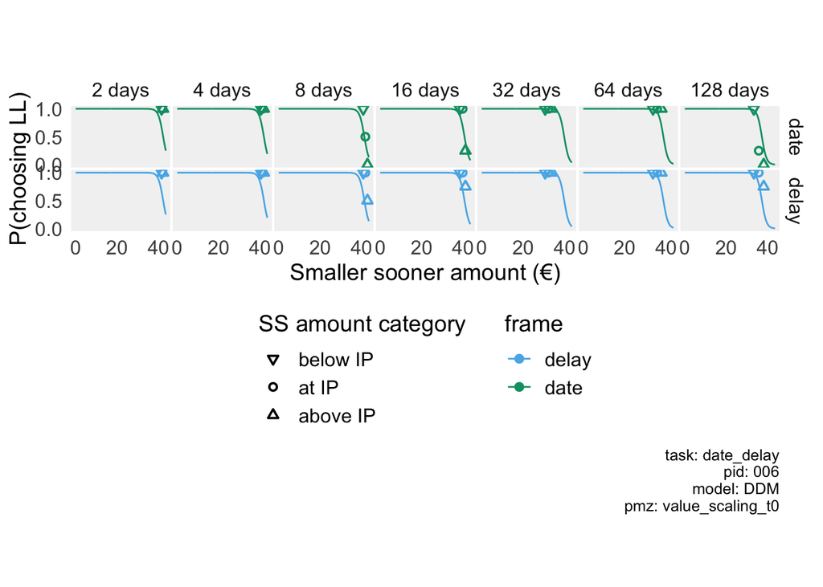

```r
if (params$visualize) {
  plt_obs_prd_ll_choices_separate <-
    ggplot2::ggplot(data = prd_pll_for_plot,
                    ggplot2::aes(x = m_s,
                                 y = p_ll,
                                 color = frame)) +
    # ggplot2::facet_grid(t_l ~ frame) +
    ggplot2::facet_grid(frame ~ t_l) +
    ggplot2::geom_line() +
    ggplot2::geom_point(data = obs_for_plotting,
                        ggplot2::aes(x = m_s,
                                     y = p_ll,
                                     color = frame,
                                     shape = m_s_cat),
                        stroke = 1) +
    ggplot2::scale_x_continuous(name = "Smaller sooner amount (€)",
                                breaks = c(0, 20, 40),
                                limits = c(0,43.52)
                                ) +
    ggplot2::scale_y_continuous(name = "P(choosing LL)",
                                breaks = seq(0,1,0.5),
                                limits = c(0,1)) +
    ggplot2::scale_shape_manual(name = "SS amount category",
                                values = c(6,1,2)) +
    ggplot2::scale_color_manual(values = cmdsddfeitc::get_aes_values("color", parameterization)) +

    # Title
    ggplot2::labs(caption = sprintf("task: %s\npid: %.3d\nmodel: %s\npmz: %s",
                                       task_version,
                                       params$participant_id, # pid
                                       params$model_name, # model
                                       params$parameterization) # parameterization
                  ) +
    cmdsddfeitc::theme_cmfsddfeitc() +
    ggplot2::theme(legend.position = "bottom",
                   legend.direction = "vertical",
                   legend.box = "horizontal")
    # ggplot2::theme(legend.position = "right")

  print(plt_obs_prd_ll_choices_separate)
}
```

### 6.2.2 Median response times

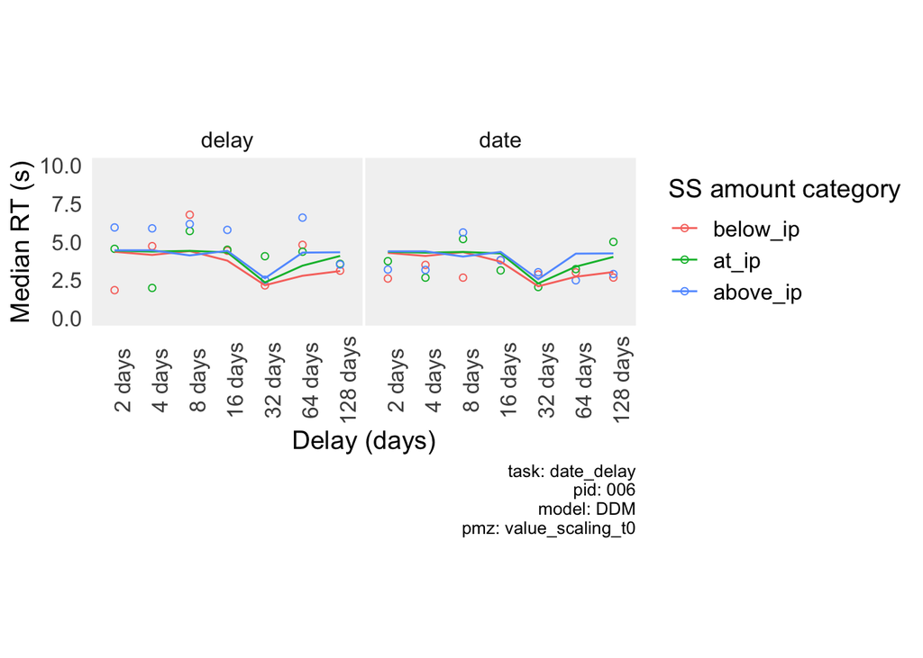

```r
if (params$visualize & params$model_name %in% c("DDM", "DFT_CRT")) {
  plt_obs_prd_rt <-
    ggplot2::ggplot(obs_mdrt_for_plot,
                    ggplot2::aes(x = t_l,
                                 y = med_rt,
                                 color = m_s_cat)
                    ) +
    ggplot2::facet_wrap("frame", nrow = 1) +

    # Geoms
    ggplot2::geom_point(shape = 21) +
    ggplot2::geom_line(data = prd_mdrt_for_plot,
                       ggplot2::aes(group = m_s_cat)) +
    # Scales
    ggplot2::scale_x_discrete(name = "Delay (days)") +
    ggplot2::scale_y_continuous(name = "Median RT (s)",
                                limits = c(0,10)) +
    ggplot2::scale_color_discrete(name = "SS amount category") +

    # Title
    ggplot2::labs(caption = sprintf("task: %s\npid: %.3d\nmodel: %s\npmz: %s",
                                       task_version,
                                       params$participant_id, # pid
                                       params$model_name, # model
                                       params$parameterization) # parameterization
                  ) +

    # Theme
    cmdsddfeitc::theme_cmfsddfeitc() +
    ggplot2::theme(axis.text.x = ggplot2::element_text(angle = 90))

  print(plt_obs_prd_rt)
}
```

## 6.3 Predicted indifference point by delay curves

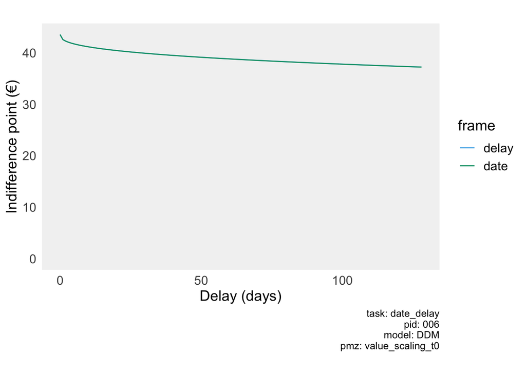

```r
if (params$visualize) {
  plt_prd_ip <-
    ggplot2::ggplot(prd_ip_data,
                    ggplot2::aes(x = delay,
                                 y = ip,
                                 color = frame)) +
    ggplot2::geom_line() +

    ggplot2::scale_color_manual(values = cmdsddfeitc::get_aes_values("color", parameterization)) +
    ggplot2::scale_x_continuous(name = "Delay (days)",
                                limits = c(0, 128)) +
    ggplot2::scale_y_continuous(name = "Indifference point (€)",
                                limits = c(0, 43.52)) +

    # Title
    ggplot2::labs(caption = sprintf("task: %s\npid: %.3d\nmodel: %s\npmz: %s",
                                       task_version,
                                       params$participant_id, # pid
                                       params$model_name, # model
                                       params$parameterization) # parameterization
                  ) +

    cmdsddfeitc::theme_cmfsddfeitc()

  print(plt_prd_ip)


}
```

# 7 Write data

The directory in which the computational modeling data will be written depends on whether the model optimization procedure converged (`optimization_converged`) or not (`optimization_nonconverged`). Visualizations are not written sepately to disk (only as part of the notebook knitted to an HTML file).

```r
if (params$optimize) {

  # Define output directory based on whether all performance criteria were met
  data_output_dir <-
    ifelse(optim_stats$converged,
           converged_models_dir,
           nonconverged_models_dir
           )

  # Write best-fitting model parameters to disk --------------------------------

  # Add relevant variables, so that these files can be read and combined into a
  # larger data frame for additional analysis
  if (params$algorithm == "DEoptim") {
    par_vals <- optim_out$optim$bestmem
    names(par_vals) <- par_names
  } else if (params$algorithm == "DEoptimR") {
    par_vals <- optim_out$par
    names(par_vals) <- par_names
  }

  par_vals_output <-
    dplyr::bind_rows(par_vals) %>%
    dplyr::mutate(participant_id = params$participant_id,
                  model_name = params$model_name,
                  parameterization = params$parameterization,
                  bound_settings = params$bound_setting,
                  algorithm = params$algorithm) %>%
    dplyr::select(participant_id, model_name, parameterization, bound_settings,
                  algorithm, dplyr::everything())

  # Make file name human- and machine-readable, so that main results can be read from file name
  best_par_val_file <-
    file.path(data_output_dir,
              sprintf("best_fitting_params_task-%s_pid-%.3d_model-%s_pmz-%s_bounds-%s_algorithm-%s_BIC-%.0f.csv",
                      task_version,
                      params$participant_id, # pid
                      params$model_name, # mode
                      params$parameterization, # pmz
                      params$bound_setting, # bounds,
                      params$algorithm, # algorithm
                      optim_stats$BIC # BIC
                      )
              )

  readr::write_csv(par_vals_output,
                   path = best_par_val_file
              )
  print(sprintf("Best-fitting model parameters: %s", best_par_val_file))

  # Write optimization statistics to disk --------------------------------------

  # Add relevant variables, so that these files can be read and combined into a
  # larger data frame for additional analysis
  optim_stats_output <-
    optim_stats %>%
    dplyr::mutate(participant_id = params$participant_id,
                  bound_settings = params$bound_setting,
                  algorithm = params$algorithm) %>%
    dplyr::select(participant_id, model, parameterization, bound_settings,
                  algorithm, dplyr::everything())


  # Make file name human- and machine-readable, so that main results can be read from file name
  optim_stats_file <-
    file.path(data_output_dir,
              sprintf("optim_stats_task-%s_pid-%.3d_model-%s_pmz-%s_bounds-%s_algorithm-%s_BIC-%.0f.csv",
                      task_version,
                      params$participant_id, # pid
                      params$model_name, # mode
                      params$parameterization, # pmz
                      params$bound_setting, # bounds
                      params$algorithm, # algorithm
                      optim_stats$BIC # BIC
                      )
              )

  # Save to disk
  readr::write_csv(optim_stats_output,
                   path = optim_stats_file
              )
  print(sprintf("Optimization statistics: %s", optim_stats_file))


  # Write evolution of parameter value across iterations to disk -----------------

  par_vals_per_iter <-
    tibble::as.tibble(par_vals_per_iter) %>%
    dplyr::mutate(participant_id = params$participant_id,
                  model_name = params$model_name,
                  parameterization = params$parameterization,
                  bound_settings = params$bound_setting,
                  algorithm = params$algorithm,
                  iter = 1:n()) %>%
    dplyr::select(participant_id, model_name, parameterization, bound_settings,
                  algorithm, iter, dplyr::everything())

  par_vals_per_iter_file <-
    file.path(data_output_dir,
              sprintf("evolution_of_params_across_iters_task-%s_pid-%.3d_model-%s_pmz-%s_bounds-%s_algorithm-%s_BIC-%.0f.csv",
                      task_version,
                      params$participant_id, # pid
                      params$model_name, # mode
                      params$parameterization, # pmz
                      params$bound_setting, # bounds
                      params$algorithm, # algorithm
                      optim_stats$BIC # BIC
              )
    )

  readr::write_csv(par_vals_per_iter,
                   path = par_vals_per_iter_file
  )

  print(sprintf("Evolution of parameter values during optimization: %s", par_vals_per_iter_file))

# Write evolution of optimization function value across iterations to disk -----

  optim_fun_val_per_iter <-
    tibble::tibble(fun_val = optim_val_per_iter) %>%
    dplyr::mutate(participant_id = params$participant_id,
                  model_name = params$model_name,
                  parameterization = params$parameterization,
                  bound_settings = params$bound_setting,
                  algorithm = params$algorithm,
                  iter = 1:n()) %>%
    dplyr::select(participant_id, model_name, parameterization, bound_settings,
                  algorithm, iter, dplyr::everything())

  optim_fun_val_per_iter_file <-
    file.path(data_output_dir,
              sprintf("evolution_of_fun_val_across_iters_task-%s_pid-%.3d_model-%s_pmz-%s_bounds-%s_algorithm-%s_BIC-%.0f.csv",
                      task_version,
                      params$participant_id, # pid
                      params$model_name, # mode
                      params$parameterization, # pmz
                      params$bound_setting, # bounds
                      params$algorithm, # algorithm
                      optim_stats$BIC # BIC
              )
    )

  readr::write_csv(optim_fun_val_per_iter,
                   path = optim_fun_val_per_iter_file
  )

  print(sprintf("Evolution of function value during optimization: %s", optim_fun_val_per_iter_file))

  # Write predicted IP data to disk --------------------------------------------

  # Add relevant variables, so that these files can be read and combined into a
  # larger data frame for additional analysis
  prd_ip_output <-
    prd_ip_data %>%
    dplyr::mutate(participant_id = params$participant_id,
                  bound_settings = params$bound_setting,
                  model = params$model_name,
                  parameterization = params$parameterization,
                  algorithm = params$algorithm) %>%
    dplyr::select(participant_id, model, parameterization, bound_settings,
                  algorithm, dplyr::everything())


  # Make file name human- and machine-readable, so that main results can be read from file name
  prd_ip_output_file <-
    file.path(data_output_dir,
              sprintf("predicted_indifference_points_task-%s_pid-%.3d_model-%s_pmz-%s_bounds-%s_algorithm-%s_BIC-%.0f.csv",
                      task_version,
                      params$participant_id, # pid
                      params$model_name, # mode
                      params$parameterization, # pmz
                      params$bound_setting, # bounds
                      params$algorithm, # algorithm
                      optim_stats$BIC # BIC
                      )
              )

  # Save to disk
  readr::write_csv(prd_ip_output,
                   path = prd_ip_output_file
              )
  print(sprintf("Indifference point data: %s", prd_ip_output_file))

  # Write area under the curve to disk -----------------------------------------

  # Add relevant variables, so that these files can be read and combined into a
  # larger data frame for additional analysis
  auc_output <-
    prds %>%
    dplyr::select(frame, auc) %>%
    tidyr::unnest() %>%
    dplyr::mutate(participant_id = params$participant_id,
                  bound_settings = params$bound_setting,
                  model = params$model_name,
                  parameterization = params$parameterization,
                  algorithm = params$algorithm,
                  norm_auc = auc / (43.52 * 128)) %>%
    dplyr::select(participant_id, model, parameterization, bound_settings,
                  algorithm, dplyr::everything())

  # Make file name human- and machine-readable, so that main results can be read from file name
  auc_output_file <-
    file.path(data_output_dir,
              sprintf("auc_task-%s_pid-%.3d_model-%s_pmz-%s_bounds-%s_algorithm-%s_BIC-%.0f.csv",
                      task_version,
                      params$participant_id, # pid
                      params$model_name, # mode
                      params$parameterization, # pmz
                      params$bound_setting, # bounds
                      params$algorithm, # algorithm
                      optim_stats$BIC # BIC
                      )
              )

  # Save to disk
  readr::write_csv(auc_output,
                   path = auc_output_file
              )
  print(sprintf("Area under the curve: %s", auc_output_file))
}
```

# 8 Write figures to disk

```r
# Resolution
dpi <- 300

# Parameter values as a function of iteration ==================================

# Filename
fn_plt_free_par_vals_per_iter_tibb <-
  sprintf("plot_evolution_of_params_across_iters_task-%s_pid-%.3d_model-%s_pmz-%s_bounds-%s_algorithm-%s_BIC-%.0f",
          task_version,
          params$participant_id, # pid
          params$model_name, # mode
          params$parameterization, # pmz
          params$bound_setting, # bounds
          params$algorithm, # algorithm
          optim_stats$BIC # BIC
          )

# As raster image --------------------------------------------------------------
ggplot2::ggsave(path = figures_dir,
                filename = paste0(fn_plt_free_par_vals_per_iter_tibb, ".png"),
                plot = plt_free_par_vals_per_iter_tibb,
                width = 18.0,
                units = "cm",
                dpi = dpi)
```

```
## Saving 18 x 12.7 cm image
```

```r
# As vector image --------------------------------------------------------------
ggplot2::ggsave(path = figures_dir,
                filename = paste0(fn_plt_free_par_vals_per_iter_tibb, ".pdf"),
                plot = plt_free_par_vals_per_iter_tibb,
                width = 18.0,
                units = "cm",
                dpi = dpi)
```

```
## Saving 18 x 12.7 cm image
```

```r
# Optimization function value as a function of iteration =======================

# Filename
fn_plt_optim_fun_val_per_iter <-
    sprintf("plot_evolution_of_fun_val_across_iters_task-%s_pid-%.3d_model-%s_pmz-%s_bounds-%s_algorithm-%s_BIC-%.0f",
            task_version,
            params$participant_id, # pid
            params$model_name, # mode
            params$parameterization, # pmz
            params$bound_setting, # bounds
            params$algorithm, # algorithm
            optim_stats$BIC # BIC
            )

# As raster image --------------------------------------------------------------
ggplot2::ggsave(path = figures_dir,
                filename = paste0(fn_plt_optim_fun_val_per_iter, ".png"),
                plot = plt_optim_val_per_iter_tibb,
                width = 8.5,
                units = "cm",
                dpi = dpi)
```

```
## Saving 8.5 x 12.7 cm image
```

```r
# As vector image --------------------------------------------------------------
ggplot2::ggsave(path = figures_dir,
                filename = paste0(fn_plt_optim_fun_val_per_iter, ".pdf"),
                plot = plt_optim_val_per_iter_tibb,
                width = 8.5,
                units = "cm",
                dpi = dpi)
```

```
## Saving 8.5 x 12.7 cm image
```

```r
# Predicted and observed probability of LL choice - compressed format ==========

# Filename
fn_plt_obs_prd_ll_choices_compressed <-
    sprintf("plot_prd_obs_prob_ll_choice_compressed_task-%s_pid-%.3d_model-%s_pmz-%s_bounds-%s_algorithm-%s_BIC-%.0f",
            task_version,
            params$participant_id, # pid
            params$model_name, # mode
            params$parameterization, # pmz
            params$bound_setting, # bounds
            params$algorithm, # algorithm
            optim_stats$BIC # BIC
            )

# As raster image --------------------------------------------------------------
ggplot2::ggsave(path = figures_dir,
                filename = paste0(fn_plt_obs_prd_ll_choices_compressed, ".png"),
                plot = plt_obs_prd_ll_choices_compressed,
                width = 18.0,
                units = "cm",
                dpi = dpi)
```

```
## Saving 18 x 12.7 cm image
```

```r
# As vector image --------------------------------------------------------------
ggplot2::ggsave(path = figures_dir,
                filename = paste0(fn_plt_obs_prd_ll_choices_compressed, ".pdf"),
                plot = plt_obs_prd_ll_choices_compressed,
                width = 18.0,
                units = "cm",
                dpi = dpi)
```

```
## Saving 18 x 12.7 cm image
```

```r
# Predicted and observed probability of LL choice - expanded format ============

# Filename
fn_plt_obs_prd_ll_choices_separate <-
    sprintf("plot_prd_obs_prob_ll_choice_separate_task-%s_pid-%.3d_model-%s_pmz-%s_bounds-%s_algorithm-%s_BIC-%.0f",
            task_version,
            params$participant_id, # pid
            params$model_name, # mode
            params$parameterization, # pmz
            params$bound_setting, # bounds
            params$algorithm, # algorithm
            optim_stats$BIC # BIC
            )

# As raster image --------------------------------------------------------------
ggplot2::ggsave(path = figures_dir,
                filename = paste0(fn_plt_obs_prd_ll_choices_separate, ".png"),
                plot = plt_obs_prd_ll_choices_separate,
                width = 18.0,
                units = "cm",
                dpi = dpi)
```

```
## Saving 18 x 12.7 cm image
```

```r
# As vector image --------------------------------------------------------------
ggplot2::ggsave(path = figures_dir,
                filename = paste0(fn_plt_obs_prd_ll_choices_separate, ".pdf"),
                plot = plt_obs_prd_ll_choices_separate,
                width = 18.0,
                units = "cm",
                dpi = dpi)
```

```
## Saving 18 x 12.7 cm image
```

```r
# Predicted and observed median response time ==================================

# Filename
fn_plt_obs_prd_rt <-
    sprintf("plot_prd_obs_rt_task-%s_pid-%.3d_model-%s_pmz-%s_bounds-%s_algorithm-%s_BIC-%.0f",
            task_version,
            params$participant_id, # pid
            params$model_name, # mode
            params$parameterization, # pmz
            params$bound_setting, # bounds
            params$algorithm, # algorithm
            optim_stats$BIC # BIC
            )

# As raster image --------------------------------------------------------------
ggplot2::ggsave(path = figures_dir,
                filename = paste0(fn_plt_obs_prd_rt, ".png"),
                plot = plt_obs_prd_rt,
                width = 18.0,
                units = "cm",
                dpi = dpi)
```

```
## Saving 18 x 12.7 cm image
```

```r
# As vector image --------------------------------------------------------------
ggplot2::ggsave(path = figures_dir,
                filename = paste0(fn_plt_obs_prd_rt, ".pdf"),
                plot = plt_obs_prd_rt,
                width = 18.0,
                units = "cm",
                dpi = dpi)
```

```
## Saving 18 x 12.7 cm image
```

```r
# Predicted indifference points ================================================

fn_plt_prd_ip <-
    sprintf("plot_predicted_indifference_points_task-%s_pid-%.3d_model-%s_pmz-%s_bounds-%s_algorithm-%s_BIC-%.0f",
            task_version,
            params$participant_id, # pid
            params$model_name, # mode
            params$parameterization, # pmz
            params$bound_setting, # bounds
            params$algorithm, # algorithm
            optim_stats$BIC # BIC
            )

# As raster image --------------------------------------------------------------
ggplot2::ggsave(path = figures_dir,
                filename = paste0(fn_plt_prd_ip, ".png"),
                plot = plt_prd_ip,
                width = 8.5,
                units = "cm",
                dpi = dpi)
```

```
## Saving 8.5 x 12.7 cm image
```

```r
# As vector image --------------------------------------------------------------
ggplot2::ggsave(path = figures_dir,
                filename = paste0(fn_plt_prd_ip, ".pdf"),
                plot = plt_prd_ip,
                width = 8.5,
                units = "cm",
                dpi = dpi)
```

```
## Saving 8.5 x 12.7 cm image
```